# Introduction to Unix Command-line - Part 1

Natalie Elphick

April 17th

*Press the ? key for tips on navigating these slides*

## Introductions

**Natalie Elphick**  
Bioinformatician I

**Yihang Xin (TA)**  
Software Engineer II

# The Unix Command-line

## What is Unix?

- A family of operating systems that date back to 1970s
- Designed to run on different types of computer hardware
- macOS and Linux are descendants of Unix
- Often used in industry and scientific research

## What is the Command-line?

- A text-based interface for interacting with the operating system
- Execute commands to perform various tasks like:
  - Navigating the file system
  - Editing files
- Command-line interfaces (CLIs) are how users interacted with computers before graphical interfaces like Windows

## Advantages of using CLIs

- Allows for automation and batch processing of data
- Provides more control and flexibility over data manipulation
- Interact with High-Performance Computing clusters (HPCs) like Wynton
- Speed

## The Terminal

- The software that provides access to the CLI
- Open your terminal
  - Mac: press Cmd + Space and type “terminal”
  - Linux: press Ctrl+Alt+T
  - Windows: open the Ubuntu app

## Download the workshop materials

- Copy and paste each of these into your terminal, press enter after each one:

```
mkdir unix_workshop
```

```
cd unix_workshop
```

```
curl -L -o unix_workshop_2023.tar.gz https://www.dropbox.com/s/smb12au2y82jmvq/unix_workshop_2023.tar.gz?dl=0
```

```
tar -xzf unix_workshop_2023.tar.gz
```

```
cd unix_workshop_2023
```

## The shell

- A shell is a specific type of CLI that provides access to the OS as a whole
- There are several different Unix shells
  - Bash : The most widely used and the default shell on most Linux systems
  - Zsh : an extended version of Bash and is now the default on newer versions of macOS

## The shell

- Check which shell you are using by typing:

```
echo $0
```

```
bash
```

Both bash and zsh should be able to run all of the commands in this workshop.

## Commands

Shell commands are basic instructions used to perform specific tasks.

Basic structure of commands:  
`command_name -[option(s)] [argument(s)]`

Example:

```
ls -lah part_1
```

Here we are providing multiple options to the `ls` command and the directory **part_1** as an argument

## man: pull up the manual page for a command

```
man echo
```

```
ECHO(1)             General Commands Manual            ECHO(1)

NAME
     echo – write arguments to the standard output

SYNOPSIS
     echo [-n] [string ...]

DESCRIPTION
     The echo utility writes any specified operands, separated by single blank
     (‘ ’) characters and followed by a newline (‘\n’) character, to the
     standard output.

     The following option is available:

     -n    Do not print the trailing newline character.  This may also be
       achieved by appending ‘\c’ to the end of the string, as is done by
       iBCS2 compatible systems.  Note that this option as well as the
       effect of ‘\c’ are implementation-defined in IEEE Std 1003.1-2001
       (“POSIX.1”) as amended by Cor. 1-2002.  Applications aiming for
       maximum portability are strongly encouraged to use printf(1) to
       suppress the newline character.

     Some shells may provide a builtin echo command which is similar or
     identical to this utility.  Most notably, the builtin echo in sh(1) does
     not accept the -n option.  Consult the builtin(1) manual page.

EXIT STATUS
     The echo utility exits 0 on success, and >0 if an error occurs.

SEE ALSO
     builtin(1), csh(1), printf(1), sh(1)

STANDARDS
     The echo utility conforms to IEEE Std 1003.1-2001 (“POSIX.1”) as amended
     by Cor. 1-2002.

macOS 13.2          April 12, 2003              macOS 13.2
```

## Manual pages

Use the arrow keys to navigate the manual and press `q` to close it

[output not shown]

## echo: print a string or value of a variable

- **Variables** : a named container that holds a value or data
- **Strings** : sequence of characters

```
message="Hello, World!"
echo $message
```

```
Hello, World!
```

Here, we assign the string “Hello, World!” to the variable `message` and use echo to print its value.

## history: list previously run commands

- You can also cycle through previously run commands using the up and down arrow keys
- By default bash stores the last 500 commands, zsh stores the last 1000

```
history
```

- Use the command `clear` to clear the output from the terminal

# Navigating the File System

## The File System

## Paths

- Root directory /
- Current working directory .
- Directory above the current one ..
- User home directory ~
- Absolute: The path starting from root

```
/data/file1.txt
```

- Relative: Path from the current directory

```
file1.txt
./file1.txt
```

## pwd: print working directory

```
pwd
```

```
/Users/your_username/unix_workshop_2023
```

- The default working directory when you log in or open a terminal is your user home directory ~

## ls: list contents of a directory

```
ls .
```

```
part_1
part_2
```

- `-l` show more information (file permissions and size)
- `-a` show all (hidden files)
- `-h` file sizes in human readable format (e.g., 1K, 2G)

```
ls -lah part_1
```

```
total 8
drwx---rw-@ 4 nelphick  staff   128B Apr 14 11:25 .
drwxr-xr-x@ 5 nelphick  staff   160B Apr 14 11:25 ..
-rw-r--rw-@ 1 nelphick  staff     0B Apr 11 16:29 .hidden_file.txt
-rw-r--rw-@ 1 nelphick  staff    60B Apr 12 15:40 list_numbers.tsv
```

## cd: move to a directory

```
cd unix_workshop_2023/part_1
ls -l
```

```
total 8
-rw-r--rw-@ 1 nelphick  staff  60 Apr 12 15:40 list_numbers.tsv
```

```
cd ..
ls -l
```

```
total 0
drwx---rw-@ 4 nelphick  staff  128 Apr 14 11:25 part_1
drwxr-xr-x@ 2 nelphick  staff   64 Apr 14 11:25 part_2
```

# Creating and Altering Files

## File Permissions

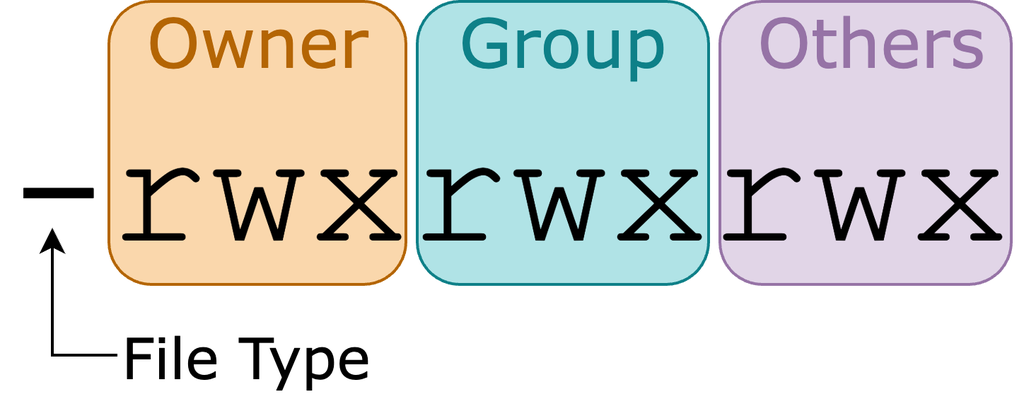

- Permissions for a file or folder are represented by 10 characters
- Each group of 3 represents the permissions for different users:
  - Owner of the file/folder
  - Group the owns the file
  - Others - everyone else

## File Permissions

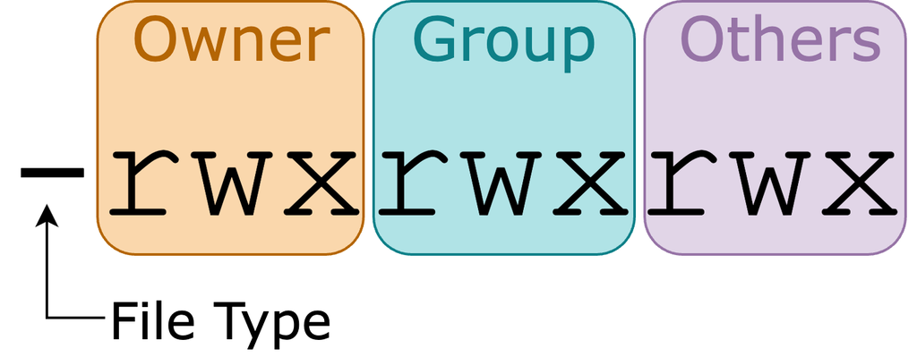

- There are three types of permissions:
  - r - read/view the contents of a file/folder
  - w - write
  - x - execute the file or access a directory

## touch: create an empty file

```
touch new_file.txt
```

- If the file exists, it will update the time stamp

## mkdir: make a directory

```
mkdir new_directory
```

- `-p` make parent directories if they don’t exist

## mv: move a file or folder

```
mv new_file.txt new_directory
```

- Also used to rename files/folders

```
mv new_directory/new_file.txt new_directory/new_file1.txt
```

## cp: copy a file or folder

```
cp new_directory/new_file1.txt new_directory/new_file2.txt
```

- `-r` to copy a folder (recursive)

## rm: remove a file permanently

- This command should always be used with care since the files it is used on **cannot be recovered**

```
rm new_directory/new_file2.txt
```

## du: check the size of a file or folder

```
du -h */*
```

```
  0B    new_directory/new_file1.txt
4.0K    part_1/list_numbers.tsv
```

-h - Displays the output in human readable format

## Check-in

If you are following along with the commands we have run so far, this is the file structure you should have:

```
ls ./*
```

```
./new_directory:
new_file1.txt

./part_1:
list_numbers.tsv

./part_2:
```

- `*` is a wildcard so `ls` will list and directories in the current one

## Text editors

- Command-line text editors provide lots of key board shortcuts to navigate and alter files
- Some commonly used ones are:
  - Vim : Feature rich, steep learning curve
  - nano : Simple and user friendly

## nano

```
nano new_directory/new_file1.txt
```

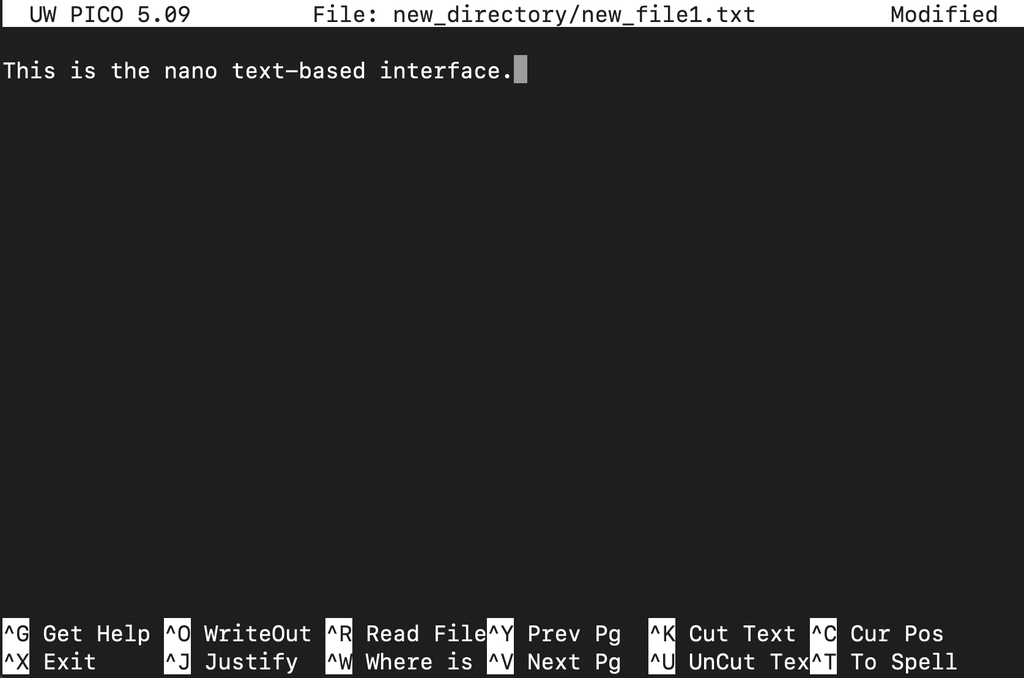

## Shortcuts for nano

- Ctrl + X : Exit nano
- Ctrl + O : Save the file (write Out)
- Ctrl + W : Search for a string or regular expression
- Ctrl + K : Cut (remove) the current line or selection
- Ctrl + U : Uncut (paste) the most recently cut text
- Ctrl + A : Move the cursor to the start of the current line
- Ctrl + E : Move the cursor to the end of the current line
- Ctrl + G : Show the help menu

# Installing Software

## Package managers

- Used to install and manage software
- macOS
  - [homebrew](https://brew.sh/) - not included with the OS and needs to be installed
- WSL/Linux
  - [apt-get](https://help.ubuntu.com/community/AptGet/Howto) - included with Ubuntu

We will not install any software in this workshop but these are how you would access additional software/commands.

# Downloading Files

## curl: download files from the internet

- We used curl at the begining download the materials
- curl supports multiple protocols but the most commonly used one is HTTPS

```
curl -o part_2/homo_sapiens.refseq.tsv.gz https://ftp.ensembl.org/pub/current_tsv/homo_sapiens/Homo_sapiens.GRCh38.109.refseq.tsv.gz
```

- `-o` gives the output file name and location

## Other file transfer tools

- wget : like curl, supports fewer protocols and is not always installed
- scp (secure copy) : used to encrypt and transfer files using SSH protocol
  - Commonly used to transfer files on HPCs (Wynton) Example:

```
scp /path/to/local/file user@remote.host:/path/to/remote/directory
```

# Searching Files and Combining Commands

## grep: searching files with regular expressions

- Search the contents of the input file and returns the lines that have a match
- **Regular Expressions** : sequence of characters that forms a search pattern

```
grep "7" part_1/list_numbers.tsv
```

```
7   8   52  13  6   42  79  1
13  4   9   82  67  71  93  3
```

## grep options

- -i : ignore case
- -v : invert match
- -r : recursively searches in all files and subdirectories of a directory
- -c : counts the number of matches found in each file

## Regular Expressions

- For a more extensive overview of regular expressions click [here](https://v4.software-carpentry.org/regexp/index.html)
- Some basic ones are:
  - ” ^ ” Matches the beginning of a line
  - ” . ” Matches any single character except newline
  - ” $ ” Matches the end of a line

```
grep "3$" part_1/list_numbers.tsv
```

```
1   3   6   10  11  22  0   3
13  4   9   82  67  71  93  3
```

## head/tail: view the first or last n lines of a file

```
head -n 1 part_1/list_numbers.tsv
```

```
1   3   6   10  11  22  0   3
```

```
tail -n 1 part_1/list_numbers.tsv
```

```
13  4   9   82  67  71  93  3
```

- The default n is 10
- Useful for getting a look at the format of a file

## cat: print the contents of a file

```
cat part_1/list_numbers.tsv
```

```
1   3   6   10  11  22  0   3
7   8   52  13  6   42  79  1
13  4   9   82  67  71  93  3
```

## cut: get specific columns from a file

```
cut -f 1-3,6 part_1/list_numbers.tsv
```

```
1   3   6   22
7   8   52  42
13  4   9   71
```

- -f : fields that should be returned
- -d : delimiter - character that the columns are separated by

By default `cut` expects columns to be separated by tab characters.

## Combining Commands

- Pipes “|” connect one command to another
- The output of the previous command is used as the input for the next one
- Chaining commands allows you to do complex operations on text streams

```
grep "3$" part_1/list_numbers.tsv | cut -f 1-3
```

```
1   3   6
13  4   9
```

## Output to a file

- The output of any command can be written to a file with the ” > ” character

```
grep "3$" part_1/list_numbers.tsv | cut -f 1-3 > part_1/subset_list_numbers.tsv
```

## tr: translate or substitute characters

```
cat part_1/list_numbers.tsv | tr "\t" "," > part_1/list_numbers.csv
cat part_1/list_numbers.csv
```

```
1,3,6,10,11,22,0,3
7,8,52,13,6,42,79,1
13,4,9,82,67,71,93,3
```

## Check-in

If you followed along with the commands we have run so far, you should have this directory structure:

```
ls ./*
```

```
./new_directory:
new_file1.txt

./part_1:
list_numbers.csv
list_numbers.tsv
subset_list_numbers.tsv

./part_2:
homo_sapiens.refseq.tsv.gz
```

# End of Part 1

## Other helpful commands

- `chmod` : Change the permissions of a file or directory
- `chown` : Change the owner of a file or directory
- `df` : Display information about disk usage and available space
- `ps` : Display information about running processes
- `kill` : Stop a running process
- `less` : View the contents of a file one page at a time
- `date` : prints the date and time
- `curl wttr.in` : check the weather

## Survey

- Please take some time to fill out the workshop survey: https://www.surveymonkey.com/r/DY7K5ZY

## Additional learning materials

- Software carpentry provides a self paced course:
  - [The Unix Shell](https://swcarpentry.github.io/shell-novice/)
- Free online books:
  - [The Unix Workbench](https://seankross.com/the-unix-workbench/index.html)
  - [The Linux Command Line](http://linuxcommand.org/tlcl.php)

## Upcoming Data Science Training Program Workshops

[Linear Mixed Effects Modeling](https://gladstone.org/index.php/events/linear-mixed-effects-modeling-0)  
April 24-April 25, 2023 10:00am-12:00pm PDT

[Machine Learning](https://gladstone.org/index.php/events/machine-learning)  
April 28, 2023 10:00am-12:00pm PDT

[Advanced Cytoscape Automation](https://gladstone.org/index.php/events/advanced-cytoscape-automation-2)  
May 2, 2023 1:00-4:00pm PDT

[Introduction to RNA-Seq Analysis](https://gladstone.org/index.php/events/introduction-rna-seq-analysis-4)  
May 15-May 16, 2023 9:00am-12:00pm PDT